# Red Wine Quality Exploration

## Bart Leatham

### 04/18/2017

Wine experts judge wines on a variety of categories in an attempt to quantify a wines quality. One of the categories used is the ‘balance’ of a wine. The balance consists of 4 measureable traits, sweetness, acidity, tannin and alcohol content. While personal taste will always prevail over a wine ‘experts’ opinion, this investigation into a [dataset](https://www.google.com/url?q=https://s3.amazonaws.com/udacity-hosted-downloads/ud651/wineQualityReds.csv&sa=D&ust=1492550811255000&usg=AFQjCNGNw9JZHE_6c9hEJDIGpoLyC5MSkA) containing the judgments of at least three wine experts will attempt to quantify the relationships between the traits of a balanced wine and the perceived quality rating by the judges. This dataset consists of data related to red Portuguese “Vinho Verde” wine.

#### Source of the dataset

Created by: Paulo Cortez (Univ. Minho), Antonio Cerdeira, Fernando Almeida, Telmo Matos and Jose Reis (CVRVV) @ 2009

#### Attribute Information

1 - fixed acidity (tartaric acid - g / dm^3)  
2 - volatile acidity (acetic acid - g / dm^3)  
3 - citric acid (g / dm^3)  
4 - residual sugar (g / dm^3)  
5 - chlorides (sodium chloride - g / dm^3  
6 - free sulfur dioxide (mg / dm^3)  
7 - total sulfur dioxide (mg / dm^3)  
8 - density (g / cm^3)  
9 - pH  
10 - sulphates (potassium sulphate - g / dm3)  
11 - alcohol (% by volume)  
Output variable (based on sensory data):  
12 - quality (score between 0 and 10)

#### Attribute Descriptions:

1 - fixed acidity: most acids involved with wine or fixed or nonvolatile (do not evaporate readily)

2 - volatile acidity: the amount of acetic acid in wine, which at too high of levels can lead to an unpleasant, vinegar taste

3 - citric acid: found in small quantities, citric acid can add ‘freshness’ and flavor to wines

4 - residual sugar: the amount of sugar remaining after fermentation stops, it’s rare to find wines with less than 1 gram/liter and wines with greater than 45 grams/liter are considered sweet

5 - chlorides: the amount of salt in the wine

6 - free sulfur dioxide: the free form of SO2 exists in equilibrium between molecular SO2 (as a dissolved gas) and bisulfite ion; it prevents microbial growth and the oxidation of wine

7 - total sulfur dioxide: amount of free and bound forms of S02; in low concentrations, SO2 is mostly undetectable in wine, but at free SO2 concentrations over 50 ppm, SO2 becomes evident in the nose and taste of wine

8 - density: the density of water is close to that of water depending on the percent alcohol and sugar content

9 - pH: describes how acidic or basic a wine is on a scale from 0 (very acidic) to 14 (very basic); most wines are between 3-4 on the pH scale

10 - sulphates: a wine additive which can contribute to sulfur dioxide gas (S02) levels, wich acts as an antimicrobial and antioxidant

11 - alcohol: the percent alcohol content of the wine

Output variable (based on sensory data): 12 - quality (score between 0 and 10)

# Overview of the data

```
## 'data.frame':    1599 obs. of  13 variables:
##  $ fixed.acidity       : num  7.4 7.8 7.8 11.2 7.4 7.4 7.9 7.3 7.8 7.5 ...
##  $ volatile.acidity    : num  0.7 0.88 0.76 0.28 0.7 0.66 0.6 0.65 0.58 0.5 ...
##  $ citric.acid         : num  0 0 0.04 0.56 0 0 0.06 0 0.02 0.36 ...
##  $ residual.sugar      : num  1.9 2.6 2.3 1.9 1.9 1.8 1.6 1.2 2 6.1 ...
##  $ chlorides           : num  0.076 0.098 0.092 0.075 0.076 0.075 0.069 0.065 0.073 0.071 ...
##  $ free.sulfur.dioxide : num  11 25 15 17 11 13 15 15 9 17 ...
##  $ total.sulfur.dioxide: num  34 67 54 60 34 40 59 21 18 102 ...
##  $ density             : num  0.998 0.997 0.997 0.998 0.998 ...
##  $ pH                  : num  3.51 3.2 3.26 3.16 3.51 3.51 3.3 3.39 3.36 3.35 ...
##  $ sulphates           : num  0.56 0.68 0.65 0.58 0.56 0.56 0.46 0.47 0.57 0.8 ...
##  $ alcohol             : num  9.4 9.8 9.8 9.8 9.4 9.4 9.4 10 9.5 10.5 ...
##  $ quality             : Factor w/ 6 levels "3","4","5","6",..: 3 3 3 4 3 3 3 5 5 3 ...
##  $ quality.bucket      : Factor w/ 3 levels "low","mid","high": 2 2 2 2 2 2 2 3 3 2 ...
```

```
##  fixed.acidity   volatile.acidity  citric.acid    residual.sugar
##  Min.   : 4.60   Min.   :0.1200   Min.   :0.000   Min.   : 0.900
##  1st Qu.: 7.10   1st Qu.:0.3900   1st Qu.:0.090   1st Qu.: 1.900
##  Median : 7.90   Median :0.5200   Median :0.260   Median : 2.200
##  Mean   : 8.32   Mean   :0.5278   Mean   :0.271   Mean   : 2.539
##  3rd Qu.: 9.20   3rd Qu.:0.6400   3rd Qu.:0.420   3rd Qu.: 2.600
##  Max.   :15.90   Max.   :1.5800   Max.   :1.000   Max.   :15.500
##    chlorides       free.sulfur.dioxide total.sulfur.dioxide
##  Min.   :0.01200   Min.   : 1.00       Min.   :  6.00
##  1st Qu.:0.07000   1st Qu.: 7.00       1st Qu.: 22.00
##  Median :0.07900   Median :14.00       Median : 38.00
##  Mean   :0.08747   Mean   :15.87       Mean   : 46.47
##  3rd Qu.:0.09000   3rd Qu.:21.00       3rd Qu.: 62.00
##  Max.   :0.61100   Max.   :72.00       Max.   :289.00
##     density             pH          sulphates         alcohol      quality
##  Min.   :0.9901   Min.   :2.740   Min.   :0.3300   Min.   : 8.40   3: 10
##  1st Qu.:0.9956   1st Qu.:3.210   1st Qu.:0.5500   1st Qu.: 9.50   4: 53
##  Median :0.9968   Median :3.310   Median :0.6200   Median :10.20   5:681
##  Mean   :0.9967   Mean   :3.311   Mean   :0.6581   Mean   :10.42   6:638
##  3rd Qu.:0.9978   3rd Qu.:3.400   3rd Qu.:0.7300   3rd Qu.:11.10   7:199
##  Max.   :1.0037   Max.   :4.010   Max.   :2.0000   Max.   :14.90   8: 18
##  quality.bucket
##  low :  63
##  mid :1319
##  high: 217
##
##
##
```

I converted the ‘quality’ feature to a factor as it is discrete values, and created a ‘quality.bucket’ variable with low, mid and high quality buckets for more meaningful analysis.  
It should be noted, as shown in the summary above, that there are many more datapoints falling in the ‘mid’(1319) quality bucket than ‘low’(63) or ‘high’(217). This should be considered when making any assumptions about the analysis.

# Univariate Plots Section

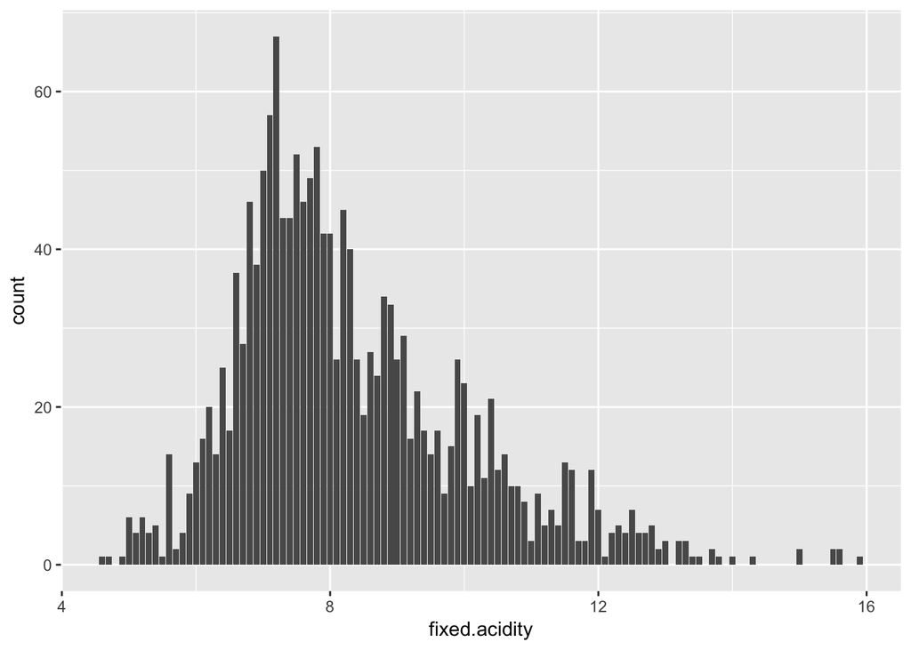

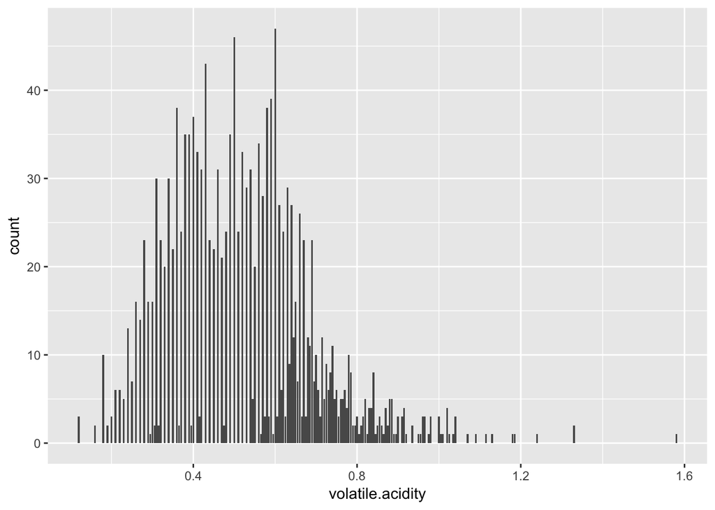

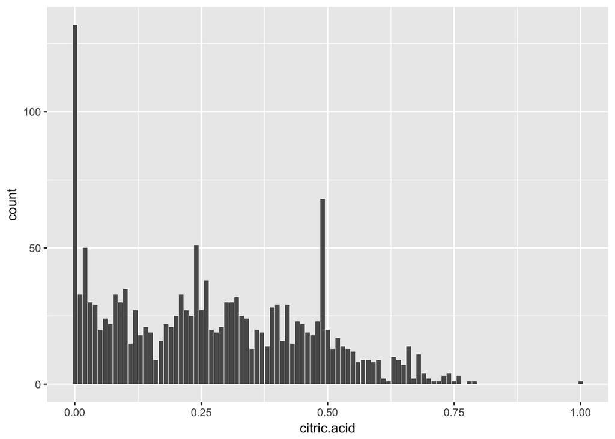

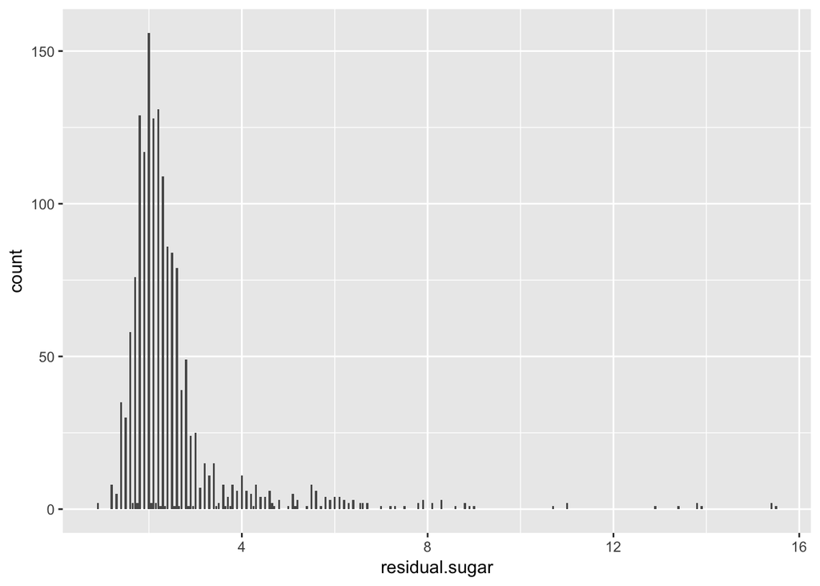

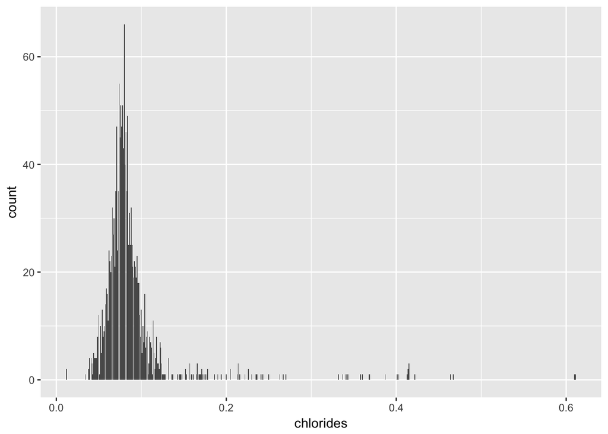

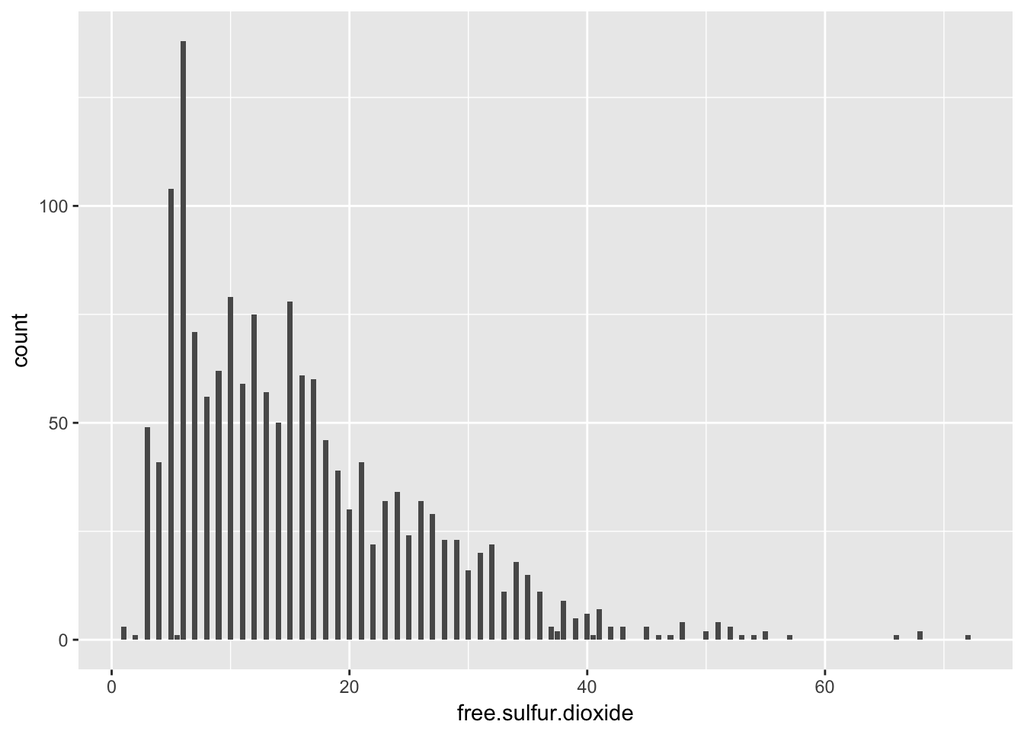

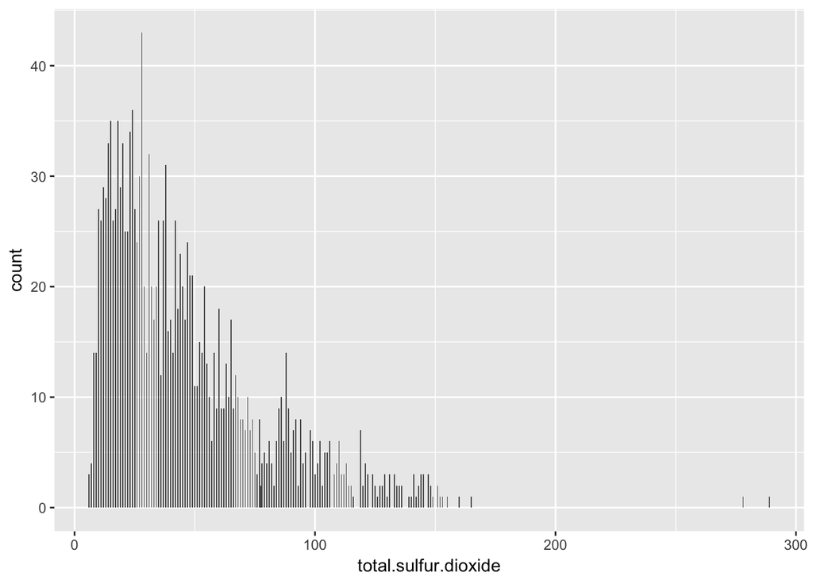

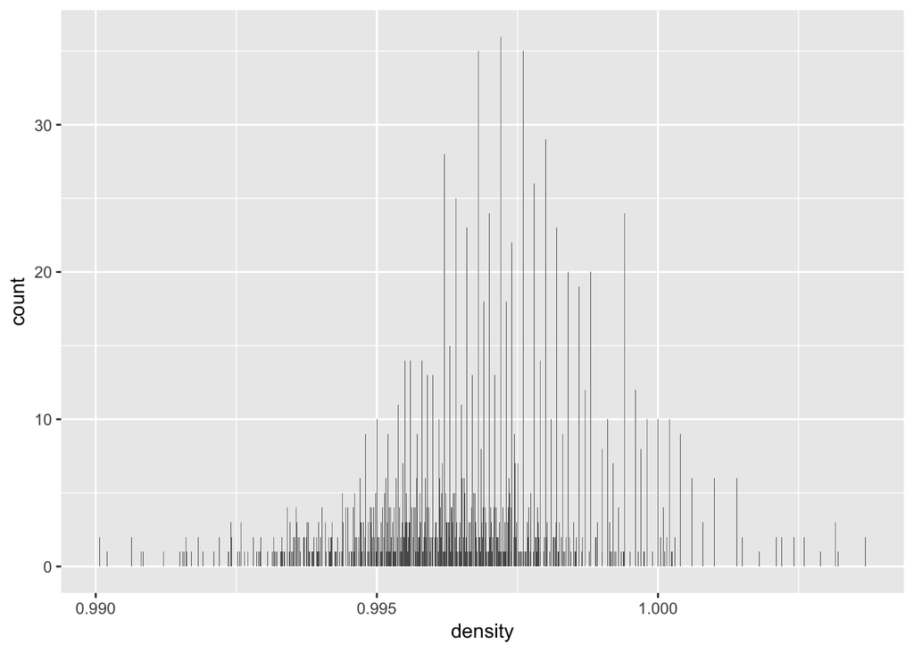

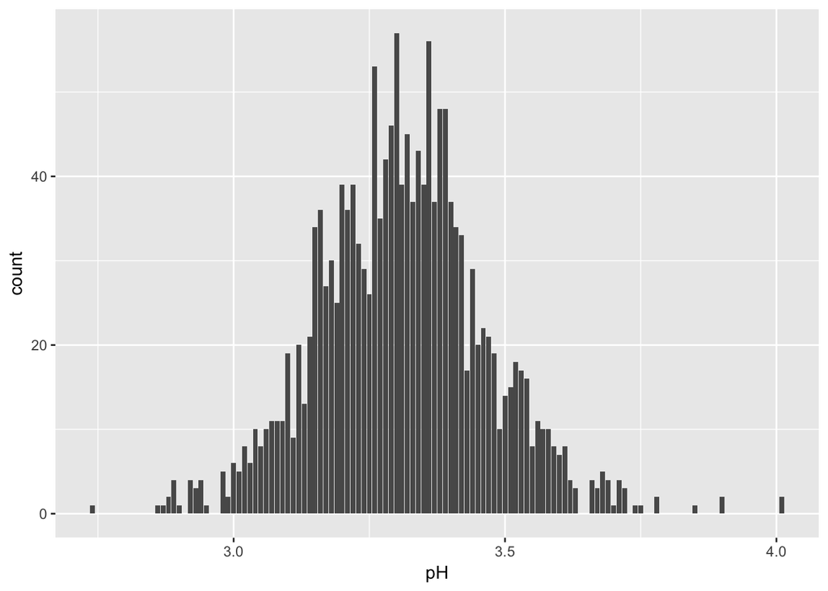

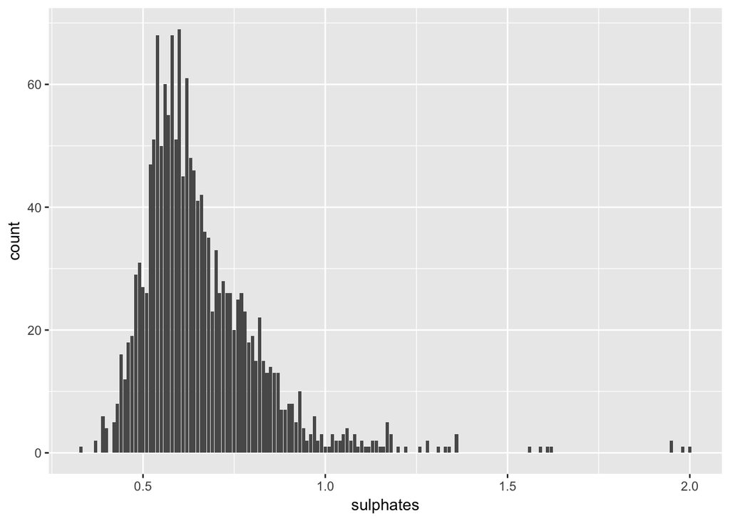

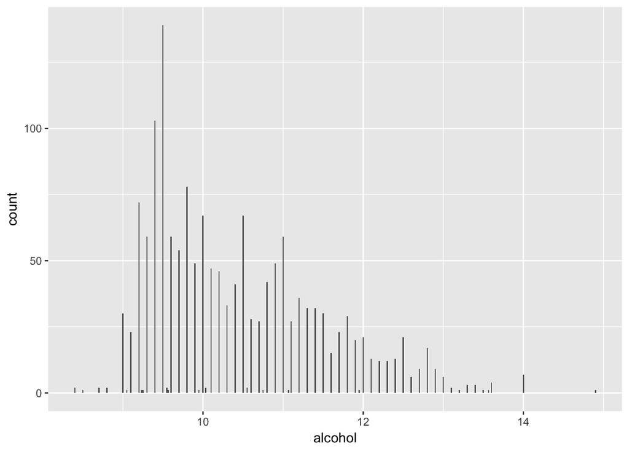

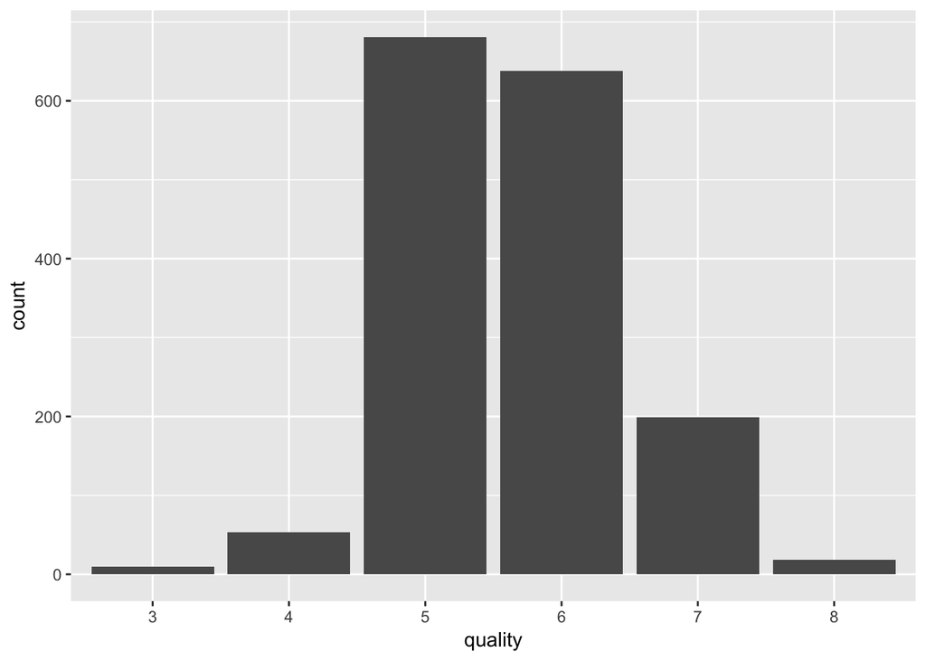

[1 more figures not shown]

# Univariate Analysis

### What is the structure of your dataset?

1599 obs. of 13 variables. 11 input variables, 2 output variables.

### What is/are the main feature(s) of interest in your dataset?

This analysis is focused on the balance of the wines, of which the traits are sweetness, acidity, tannin and alcohol. The dataset does not contain a measure for tannins, so the investigation will focus on sweetness (measured by residual.sugar), acidity (measured by pH), the alcohol content and quality rating.

### What other features in the dataset do you think will help support your investigation into your feature(s) of interest?

I am curious how the density of the wine will relate to the quality rating.

### Did you create any new variables from existing variables in the dataset?

I bucketed the quality ratings into a quality.bucket variable, with low, med, high being the buckets. This allows for a more meaningful analysis, as the counts for some quality rankings were low compared to others.

### Of the features you investigated, were there any unusual distributions? Did you perform any operations on the data to tidy, adjust, or change the form of the data? If so, why did you do this?

This dataset met tidy data requirements as delivered, so the only cleaning I performed was to remove the X column as it was just a line count index.  
Most of the features have an overall normal distribution, some skewed to the right, with a long tail of outliers.

# Bivariate Plots Section

### Correlation data

Below we see the correlation values between all input and output variables, as well as a graphical representation.

```
##                      fixed.acidity volatile.acidity citric.acid
## fixed.acidity                 1.00            -0.26        0.67
## volatile.acidity             -0.26             1.00       -0.55
## citric.acid                   0.67            -0.55        1.00
## residual.sugar                0.11             0.00        0.14
## chlorides                     0.09             0.06        0.20
## free.sulfur.dioxide          -0.15            -0.01       -0.06
## total.sulfur.dioxide         -0.11             0.08        0.04
## density                       0.67             0.02        0.36
## pH                           -0.68             0.23       -0.54
## sulphates                     0.18            -0.26        0.31
## alcohol                      -0.06            -0.20        0.11
## quality                       0.12            -0.39        0.23
##                      residual.sugar chlorides free.sulfur.dioxide
## fixed.acidity                  0.11      0.09               -0.15
## volatile.acidity               0.00      0.06               -0.01
## citric.acid                    0.14      0.20               -0.06
## residual.sugar                 1.00      0.06                0.19
## chlorides                      0.06      1.00                0.01
## free.sulfur.dioxide            0.19      0.01                1.00
## total.sulfur.dioxide           0.20      0.05                0.67
## density                        0.36      0.20               -0.02
## pH                            -0.09     -0.27                0.07
## sulphates                      0.01      0.37                0.05
## alcohol                        0.04     -0.22               -0.07
## quality                        0.01     -0.13               -0.05
##                      total.sulfur.dioxide density    pH sulphates alcohol
## fixed.acidity                       -0.11    0.67 -0.68      0.18   -0.06
## volatile.acidity                     0.08    0.02  0.23     -0.26   -0.20
## citric.acid                          0.04    0.36 -0.54      0.31    0.11
## residual.sugar                       0.20    0.36 -0.09      0.01    0.04
## chlorides                            0.05    0.20 -0.27      0.37   -0.22
## free.sulfur.dioxide                  0.67   -0.02  0.07      0.05   -0.07
## total.sulfur.dioxide                 1.00    0.07 -0.07      0.04   -0.21
## density                              0.07    1.00 -0.34      0.15   -0.50
## pH                                  -0.07   -0.34  1.00     -0.20    0.21
## sulphates                            0.04    0.15 -0.20      1.00    0.09
## alcohol                             -0.21   -0.50  0.21      0.09    1.00
## quality                             -0.19   -0.17 -0.06      0.25    0.48
##                      quality
## fixed.acidity           0.12
## volatile.acidity       -0.39
## citric.acid             0.23
## residual.sugar          0.01
## chlorides              -0.13
## free.sulfur.dioxide    -0.05
## total.sulfur.dioxide   -0.19
## density                -0.17
## pH                     -0.06
## sulphates               0.25
## alcohol                 0.48
## quality                 1.00
```

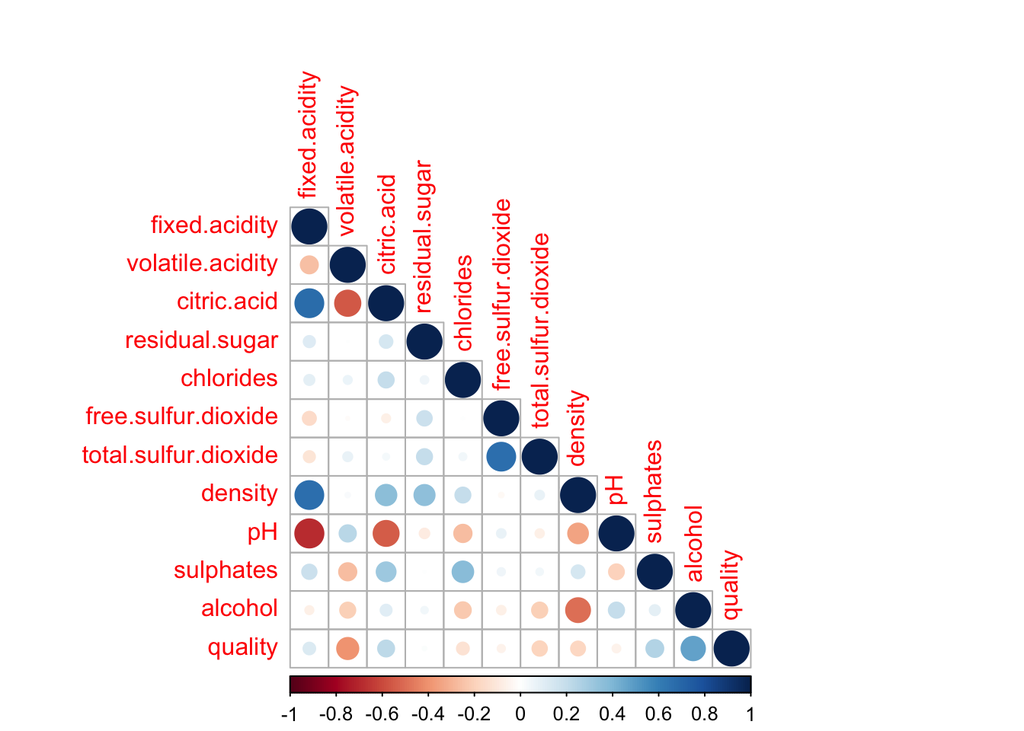

A quick look at the correlation between the variables shows that there are no strong correlations between quality and the various input variables, the strongest postive correlation being the alcohol content at r= 0.48, and the strongest negative correlation being the volatile acidity at r= -0.39.

### Bivariate Plots

After perfoming multiple plotting techniques (hist, bar, density, scatter, box) for introductory analysis, I found that using a box plot of each variable vs. quality.bucket yielded the most useful visual data for Bivariate analysis.

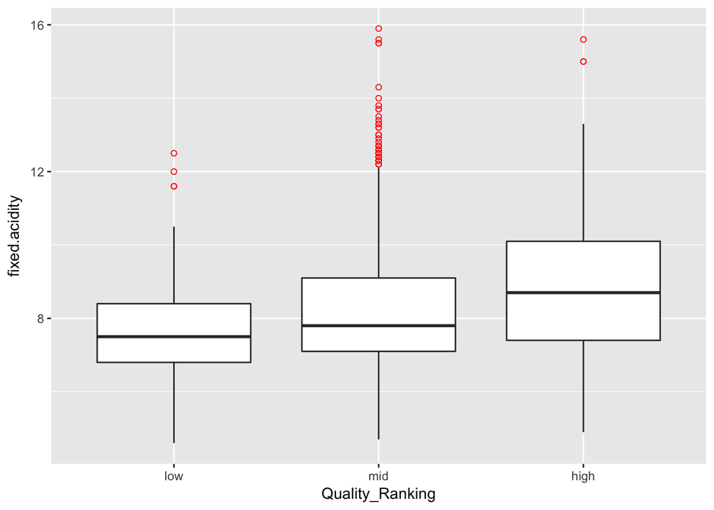

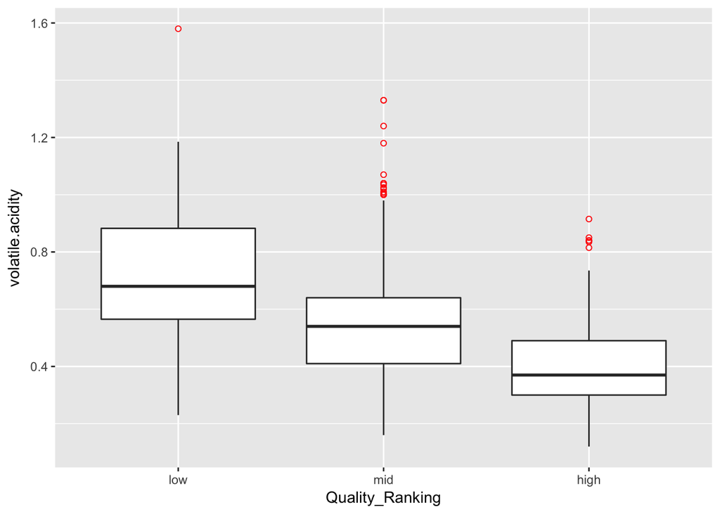

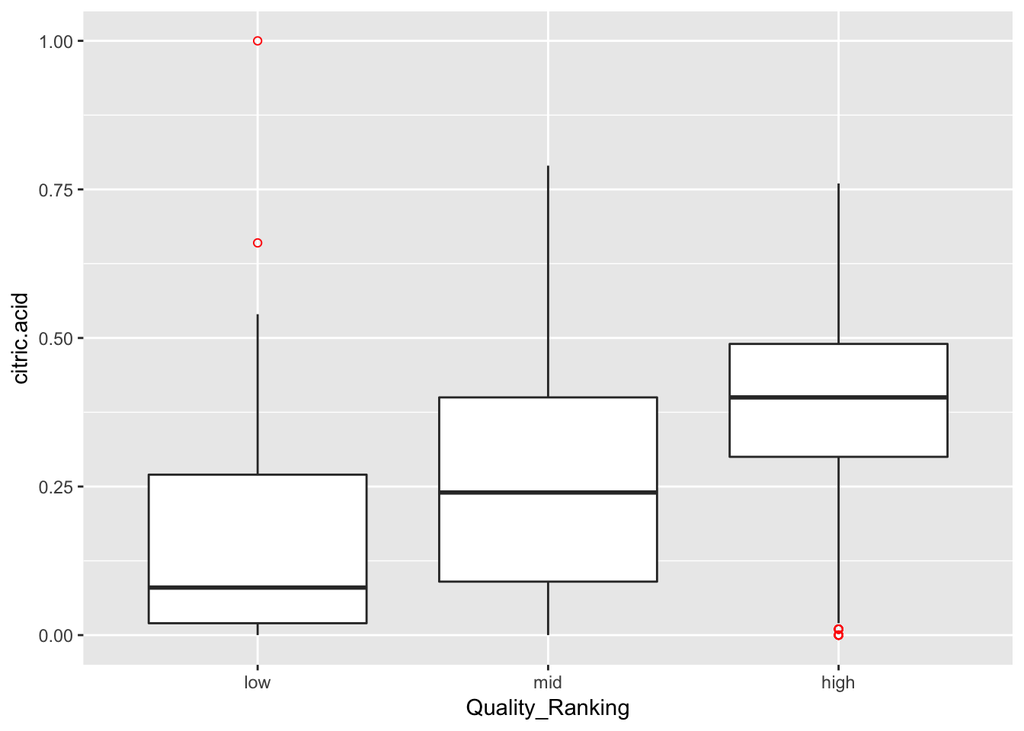

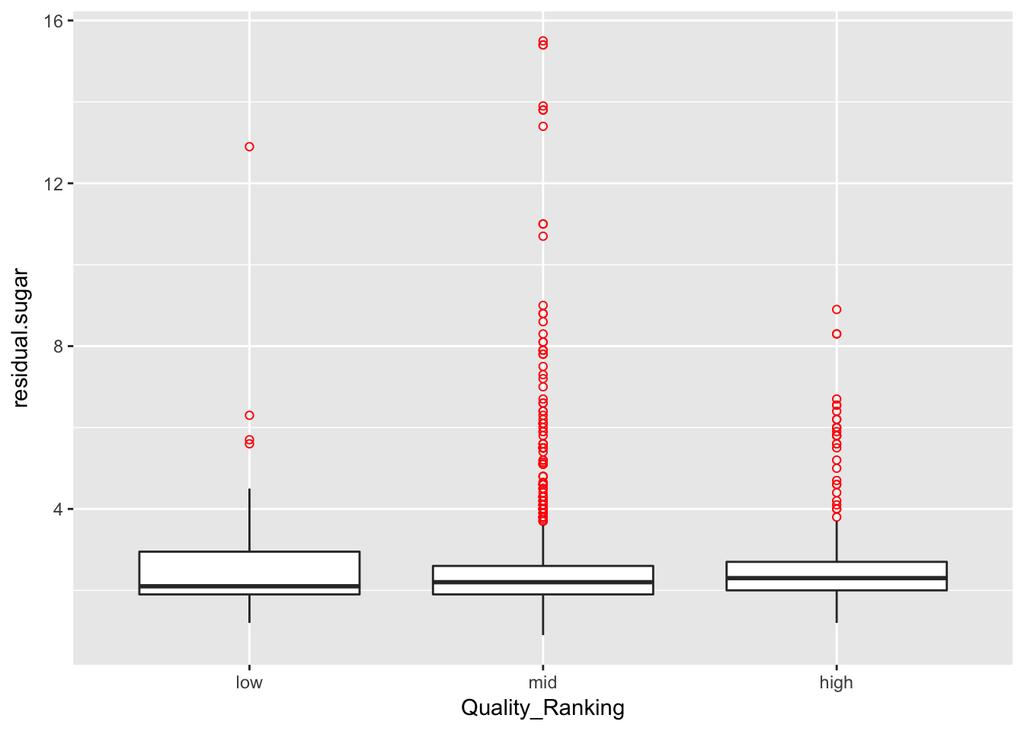

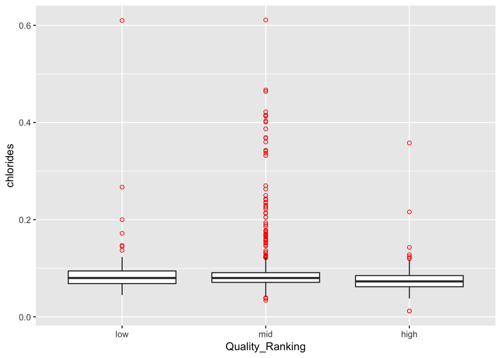

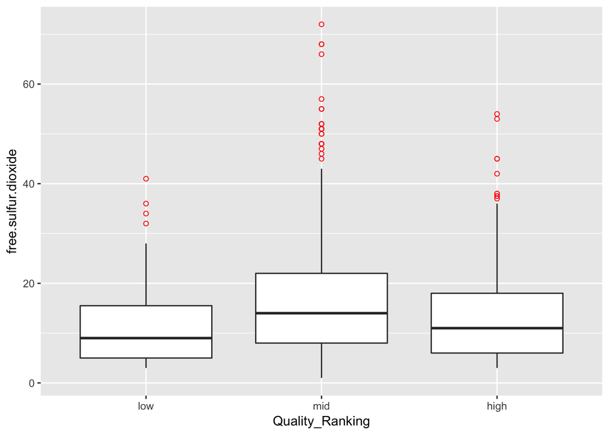

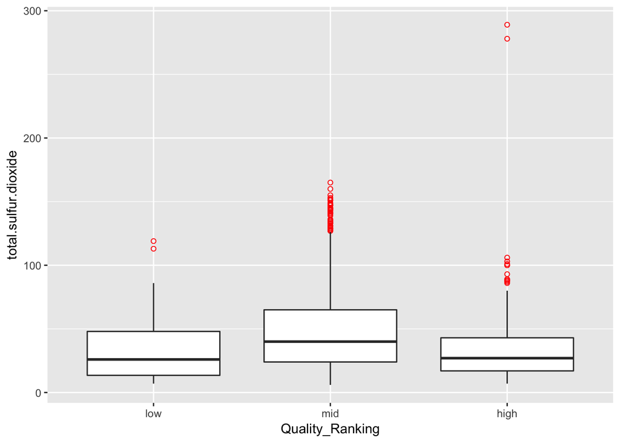

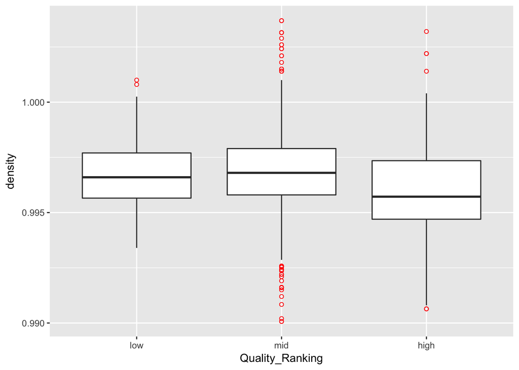

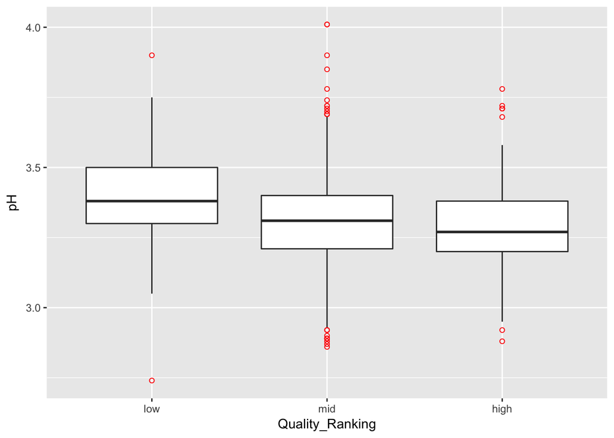

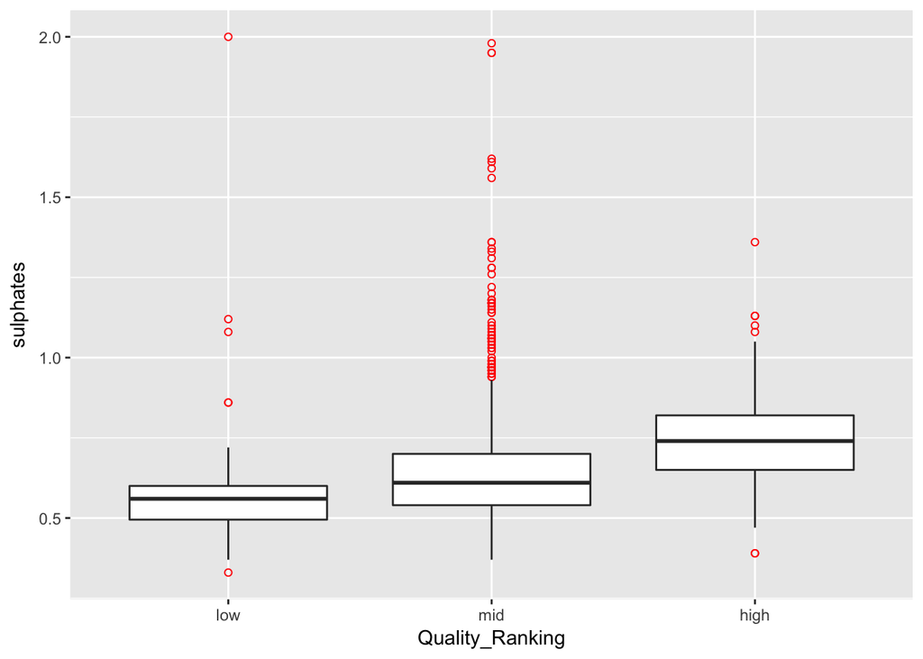

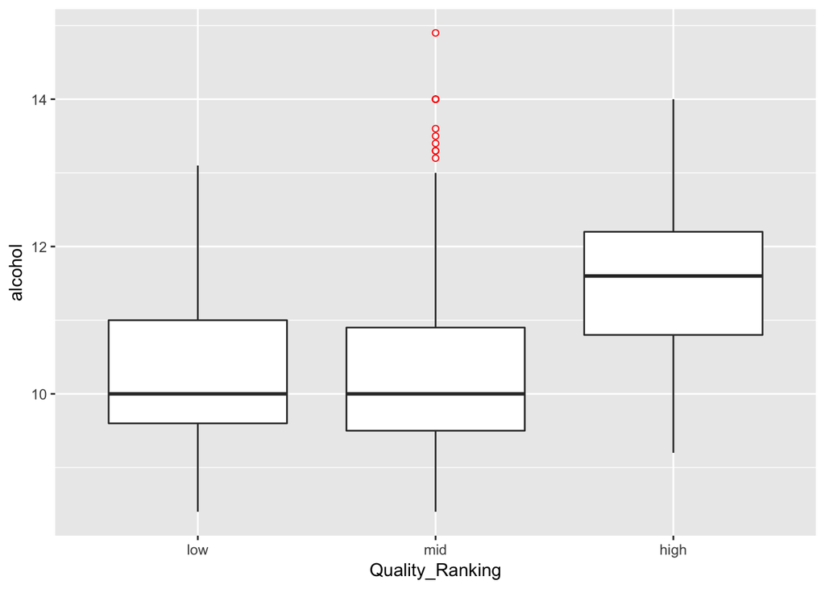

## Bivariate Analysis

Upon analyzing the above plots, we can see that the higher the chloride and volatile.acidity, the lower the quality.  
The higher the fixed.acidity, sulfates, alcohol and citric.acid, the higher the quality.  
It is interesting to note, that if relying on the box plots alone, one could infer that the variables mentioned could have a large correlation to the quality of the wine. Since we have looked at the correlation values explicity, we know that this is not case, there is a correlation, though not a strong one.

### Talk about some of the relationships you observed in this part of the investigation. How did the feature(s) of interest vary with other features in the dataset?

Of the 4 features of interest, density and alcohol content have the strongest correlations to the quality of the wine. Density has a r = -0.17 while alcohol has r = 0.48 correlation to the quality of the wine. The pH and residual sugar have low correlations (r = -0.06 and r = 0.01 respectively). I expected that the residual sugar would have more of an impact, as I often hear wines described as being too sweet.

### Did you observe any interesting relationships between the other features (not the main feature(s) of interest)?

It was interesting to see that the correlation data reinforced some relationships that would be expected. For instance, the various *.acid features have relatively strong correlations to the pH.

# Multivariate Plots Section

I was interested in looking deeper into the relationships between the residual sugar, density, pH, alcohol content and quality.

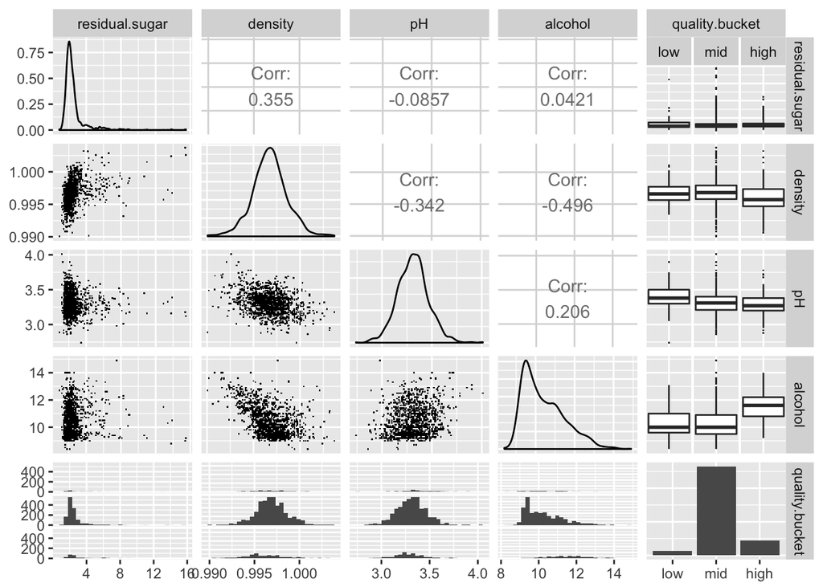

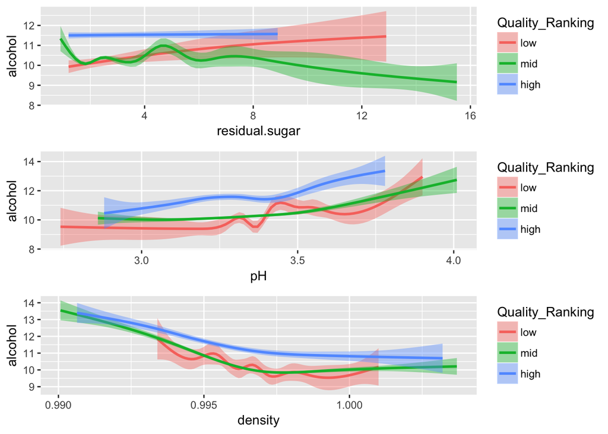

# Multivariate Analysis

# Final Plots and Summary

### Plot One

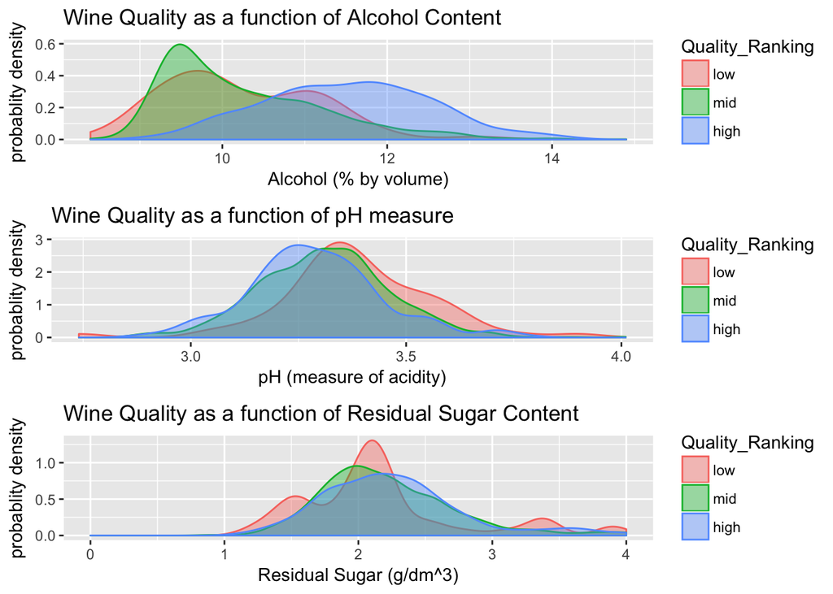

### Description One

The above plots shows the probability density of each of our traits of interest in investigating the ‘balance’ of our wine observations.  
We can see that in isolation, higher alcohol content, lower pH and slightly higher residual sugar lead to higher quality wines.

### Plot Two

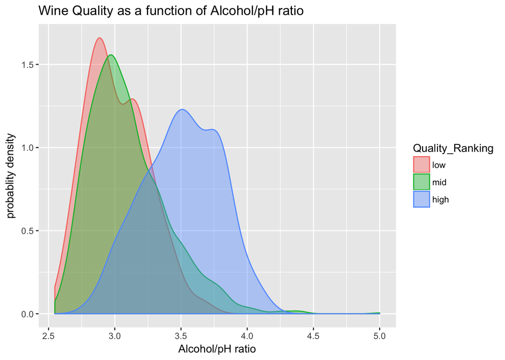

### Description Two

This plot shows the relationship between the quality of a wine and the ratio of alcohol/pH. It shows the optimum ratio of alcohol to pH as being 3.5, with a clear differentiation from the optimum ratios for low or mid ranked wines.  
This reinforces the fact that wines with a lower pH, and a higher alcohol content are ranked higher in quality in the given dataset.

### Plot Three

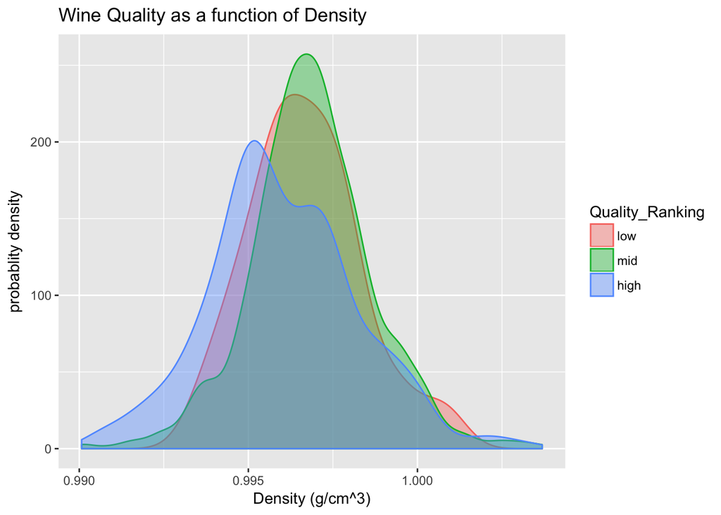

# Reflection

This red wine dataset provided 1599 observations of 11 input and 1 output variable. I first looked into the distribution of the variable values, then moved on to their correlations. Once I saw that the correlations were generally weak, especially with regard to the reported quality rating of the wine, I realized that I needed to come up with a direction to take the investigation. At that point I researched how wine quality is generally defined by experts, and decided to pursue the measure of ‘Balance’ for a wine and investigated its traits as much as possible with the data provided.  
The main struggle I faced in this investigation was the fact that none of the independant variables were statistically strongly correlated to the quality ranking of the wines.  
I was surprised to see that the features were not more strongly correlated to the quality rating of the wines. Before this investigation I would have guessed that alcohol, pH and sweetness all would have been more highly correlated with the quality rating. To me this proves that wine quality ratings are highly subjective, and a wine consumer would do best to trust their tastebuds (and wallets) over being overly concerned with how a wine expert views their choice. Future work with this dataset I would be interested in having both a measure of tannins, and the price of the wine included. Having the tannin measure available would enable the ability to create a full model of the ‘Balance’ traits. The price data would be an interesting data point to investigate, is the pricing vs quality normally distributed, or does it shift towards higher? It would also be interesting to see a dataset with more varieties of wine, to get a more broad understanding of how the features effect quality, and how the features differ between wine varieties.

# References

#many R related inqueries:  
http://www.cookbook-r.com/

#read up on factor variables:  
https://www.stat.berkeley.edu/classes/s133/factors.html

#read up on ggplot geom_density plots:  
https://www.r-bloggers.com/density-plot-with-ggplot/ http://ggplot2.tidyverse.org/reference/geom_density.html

#read up on boxplot techniques:  
http://ggplot2.tidyverse.org/reference/geom_boxplot.html

#correlation plot techniques:  
http://www.sthda.com/english/wiki/visualize-correlation-matrix-using-correlogram

#plotting lines and shapes help:  
http://www.cookbook-r.com/Graphs/Shapes_and_line_types/

#how to discern wine quality:  
http://www.dummies.com/food-drink/drinks/wine/how-to-discern-wine-quality/

#how to measure tannins in wine:  
https://www.awri.com.au/wp-content/uploads/2014/01/measuring-wine-tannins.pdf